# Introduction to Bootstrap Methods

Steve Elston

10/06/2022

# Introduction

“There were others who had forced their way to the top from the lowest rung by the aid of their bootstraps.” James Joyce, ‘Ulysses’ 1922

Bootstrap and re-sampling methods are widely applicable statistical methods

- Resampling methods are products of the computer age
- Use computational resources unimaginable in the early 20th Century
- Repeatedly re-sampling the data relaxes some of the assumptions of classical statistical methods
- Re-sampling methods draw heavily on the law of large number and the central limit theorem

# Types of Resampling Methods

Commonly used re-sampling methods include:

- **Randomization or Permutation methods:** aka exact tests
  - Have a long history; e.g. Fisher’s exact test (1922)
  - Became practical for larger data sets in computer era
- **Cross validation:** re-sample into multiple folds without replacement
  - Leave n out method
  - Has origins in the 1950s
  - Widely used to evaluate machine learning (ML) models
- **Jackknife:** leave one out re-sampling
  - Leave one out method
  - Early general purpose resampling method
  - Has origins in the 1950s
- **Bootstrap:** re-sample with equivalent size and replacement - our focus here
  - Published by Prof Brad Efron in 1979

# General Characteristics of Resampling Methods

General characteristics of resampling methods include

- Allow computation of statistics from limited data samples for statistics with continuous derivatives
- Repeatedly compute statistics from multiple resamples of dataset
- The result converges to the sample distribution of the statistic being computed
- Make minimal distributional assumptions, when compared to classical frequentist statistics

# Pitfalls of Resampling Methods

Re-sampling methods are general and powerful but, there is no magic involved! There are pitfalls!

- If a sample is biased, the re-sampled statistic estimate based on that sample will be biased
  - Results can be no better than the sample you start with
  - Example; the bootstrap estimate of mean is the unbiased sample estimate, $\bar{x}$, not the population parameter, $\mu$
- The sample variance and Cis can be no better than the sample distribution allows
  - Be suspicious of overly optimistic confidence intervals
  - CIs can be optimistically biased
- Are computationally intensive, but often highly parallelizable

# Point Estimates vs. Distribution Estimates

The goal of frequentist statistics is to compute a point estimate and confidence interval

- Point estimate is the single most likely value for a statistic
  - Confidence interval expresses the uncertainty of the point estimate
- Frequentist confidence interval based on the properties of some assumed probability distribution
  - Are there alternatives to this classical frequentist approach?
  - Here we focus on bootstrap methods which do not require explicit probability model
  - Bootstrap methods let a computer do the work, not the statistician with paper and pencil

# Bootstrap Distribution

Rather than computing a point estimate directly, bootstrap methods compute a bootstrap distribution of a statistic

- Bootstrap distribution is comprised of values of the statistic computed from bootstrap resamples of the original observations (data sample)
- Computing bootstrap distribution requires **no assumptions about population distribution!**
  - Bootstrap resampling substitutes computer power for paper and pencil statistician power
- Bootstrap resampling estimates the **bootstrap distribution** of a statistic
  - Compute mostly likely point estimate of the statistic, or bootstrap estimate
  - The bootstrap confidence interval is computed from the bootstrap distribution

# Bootstrap Distribution

Rather than repeatedly resample the population, bootstrapping repeatedly resamples an original sample

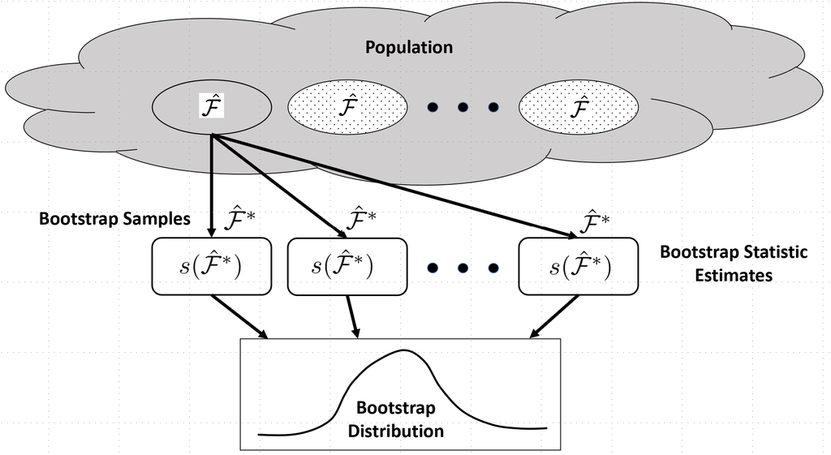

Resampling to estiamte the bootstrap distribution of a statistic

# Overview of the Bootstrap Algorithm

The bootstrap method follows a simple algorithm. Estimates of the point estimate of a statistic are accumulated by these steps:

1. Randomly **Bernoulli sample** sample n data **with replacement** from an original data sample of n values; The re-sample is the same size as the original data sample
2. Re-compute the statistic with each resample
3. Repeat steps 1 and 2 to accumulate the required number of bootstrap samples
4. Accumulated bootstrap values form the bootstrap distribution; An estimate of the sample distribution of the statistic
5. The mean of the computed statistic values is the bootstrap point estimate of the statistic
- By law of large numbers, bootstrap point estimate converges
- Efrom and Tibshirani (1993) and Efron and Hasti (2016) recommend using at least 200 bootstrap samples for point estimates
- Other authors recommend a larger number (e.g. 1,000-2,000) of resamples given low computer cost

# Overview of the Bootstrap Algorithm

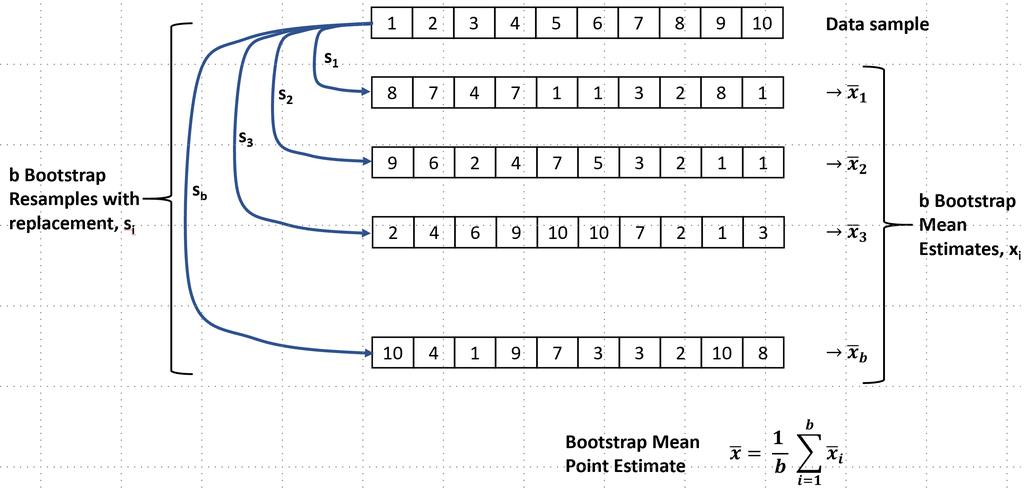

Outline of bootstrap resampling algorithm to compute mean

# Example; One Sample Bootstrap

Use sample of standardized scores of highschool students from [UCLA Statistical Consulting](https://stats.idre.ucla.edu/)

```
##      female  race  ses  schtyp  prog  read  write  math  science  socst
## id
## 70        0     4    1       1     1    57     52    41       47     57
## 121       1     4    2       1     3    68     59    53       63     61
## 86        0     4    3       1     1    44     33    54       58     31
## 141       0     4    3       1     3    63     44    47       53     56
## 172       0     4    2       1     2    47     52    57       53     61
## 113       0     4    2       1     2    44     52    51       63     61
## 50        0     3    2       1     1    50     59    42       53     61
## 11        0     1    2       1     2    34     46    45       39     36
## 84        0     4    2       1     1    63     57    54       58     51
## 48        0     3    2       1     2    57     55    52       50     51
```

# Example; One Sample Bootstrap

Histogram of the math scores

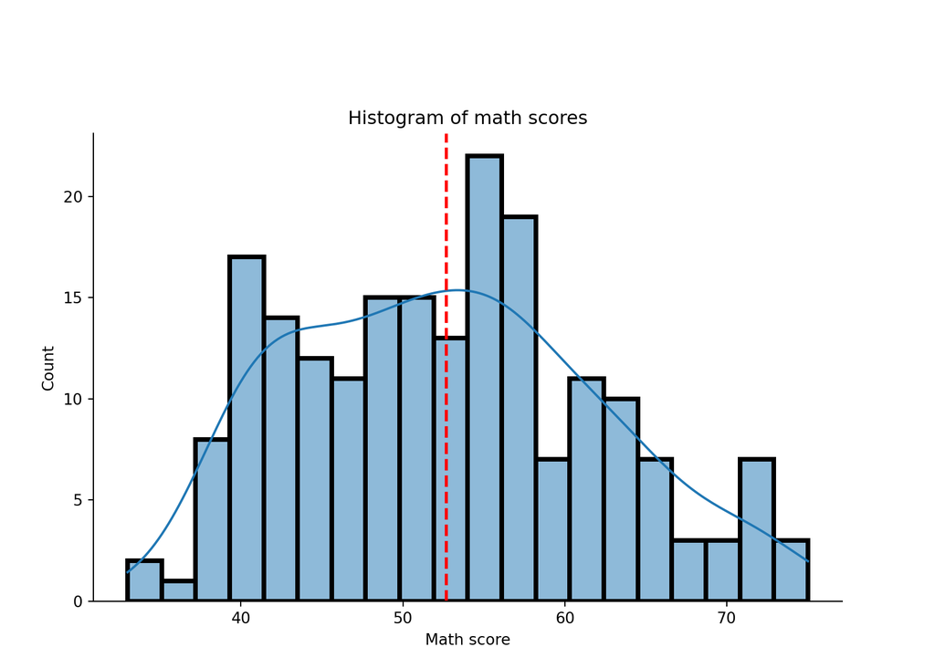

# Example; One Sample Bootstrap

Function to compute single sample bootstrap estimate of statistic

```python
def bootstrap_statistic(x, b, statistic):
    '''
    Function Computes b one-sample bootstrap estimates of data x
    using statistic function.
    '''
    n_samps = len(x)
    boot_vals = []
    for _ in range(b):
        ## The heavy work is done here. The statistic is computed
        ## using the bootstrap sample of the observations
        boot_vals.append(statistic(nr.choice(x, size=n_samps, replace=True)))
    boot_estimate = np.mean(boot_vals)
    print('Bootstrap point estimate = {:6.2f}'.format(boot_estimate))
    return(boot_estimate, boot_vals)

bootstrap_mean_estimate, boot_means = bootstrap_statistic(math, 200, np.mean)
```

```
## Bootstrap point estimate =  52.64
```

# Example; One Sample Bootstrap

Distribution of 200 bootstrap samples of mean estimates

```
## bootstrap point estimate =  52.67
```

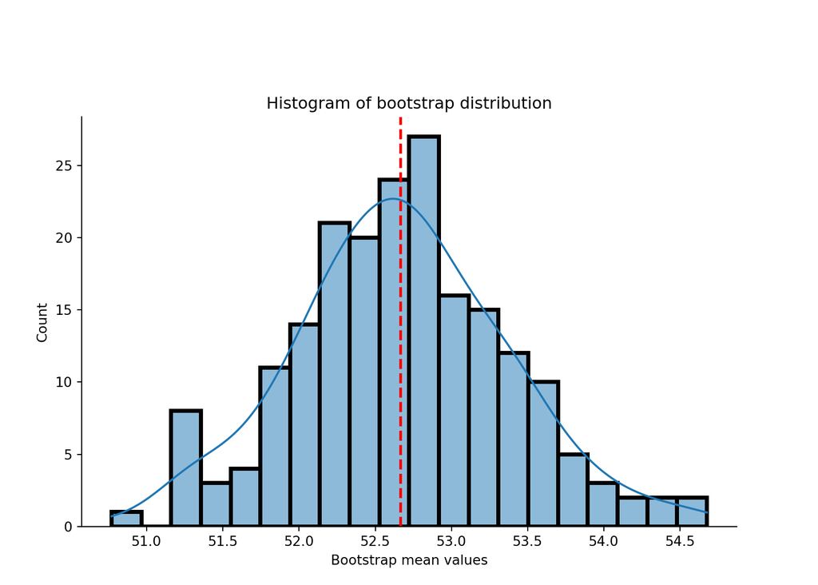

# Bootstrap Confidence Intervals

Distribution of 2000 bootstrap bootstrap confidence intervals?

- Use percentile method:
  1. Define confidence level, eg. 95% or α=0.05
  2. Order b bootstrap samples, $s_i$$, by value
  3. Lower CI index; $i = b∗α/2$
  4. Upper CI index; $i = b∗(1−α/2)$
- Percentile method is know to be biased
  - Bias correction methods available
- Efrom and Tibshirani (1993) and Efron and Hasti (2016) recommend using at least 2,000 bootstrap samples to estimate confidence intervals
- Other authors recommend a larger number (e.g. 5,000-20,000) of resamples given low computer cost

# Bootstrap Confidence Intervals

Bootstrap confidence intervals are known to be biased!

- Often bootstrap CIs are overly optimistic
- Bias can be significant for asymmetric distributions

# Example; One Sample Bootstrap

Bootstrap distribution of 2000 of mean estimates with confidence intervals

```
## bootstrap point estimate =  52.64
```

```
## At alpha = 0.05, lower and upper bootstrap confidence intervals =  51.37    53.92
```

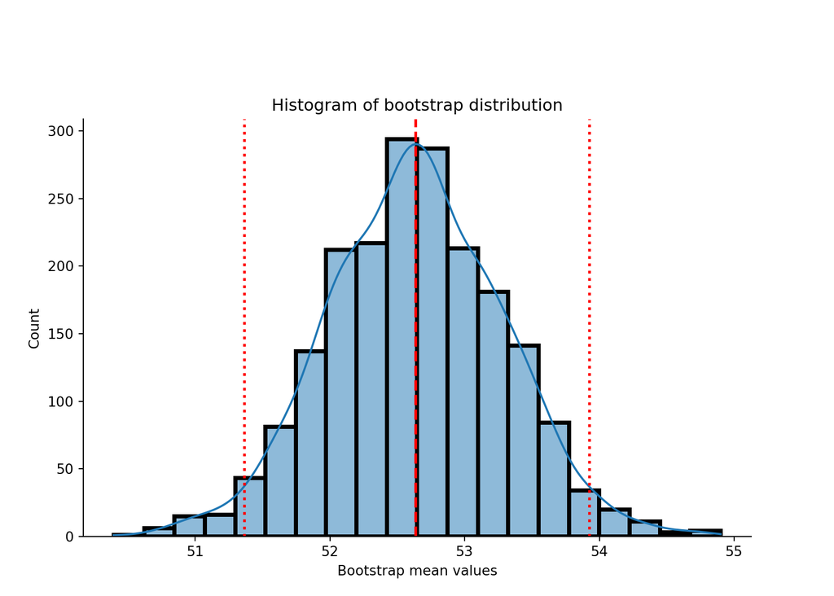

# Two Sample Bootstrap

How can we apply the bootstrap algorithm for two-sample statistics?

- Example, difference of means of two independently sampled populations
- How to generate bootstrap samples?
- Can we just sample the concatenation of the two samples?
- **No!**
  - There is no guarantee of a correct number of resamples for each group
  - Imbalanced sampling leads to bias
- Must independently sample the two groups or populations
  - Use two independent bootstrap samples to compute statistic
  - Step one; compute statistic from independent resamples
  - Step two; compute (another) statistic from the two bootstrap estimates

# Two Sample Bootstrap

Example: algorithm to compute difference of means:

1. Independently randomly sample (e.g. Bernoulli sample) n data with replacement from each original data sample; The number of resamples for each populations is the number of samples for that population
2. Compute the statistic (e.g. mean) for the two resamples
3. Compute the two-sample statistic; e.g. difference of means
4. Repeat steps 1, 2, and 3 to accumulate the required number of bootstrap samples Accumulated bootstrap values form the bootstrap distribution; an estimate of the sample distribution of the statistic
5. The mean of the computed statistic values is the bootstrap point estimate of the statistic; e.g. difference of means
6. Compute CIs from bootstrap distribution

# Two Sample Bootstrap

Example; find the bootstrap distribution of the difference in math scores between low and middle SES students.

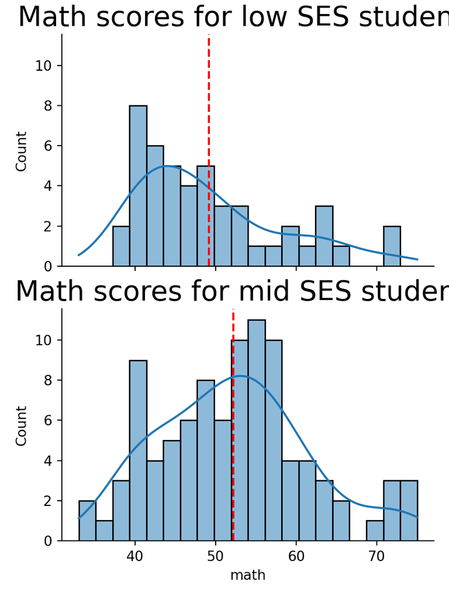

# Example, Two Sample Bootstrap

```python
def two_boot_two_stat(sample_1, sample_2, b, statistic_1, two_samp_statistic):
    '''
    Function computes two sample and two statistic bootstrap estimate.
    - sample_1 and sample_2, independent obervation vectors
    - b, number of bootstrap samples to compute
    - statistic 1, statistic applied to the two independent bootstrap samples
    - two_sample_statistic, statistic applied to the independent bootstrap statistics
    '''
    two_boot_values = []
    n_samps_1 = len(sample_1)
    n_samps_2 = len(sample_2)
    for _ in range(b):
        ## Heavy lisfting is done here. First, the two independent bootstrap estimates
        ## are computed from independent bootstrap resamples. Second, the statistic
        ## of the two bootstrap estimates is computed.
        boot_estimate_1 = statistic_1(nr.choice(sample_1, size=n_samps_1, replace=True))
        boot_estimate_2 = statistic_1(nr.choice(sample_2, size=n_samps_2, replace=True))
        two_boot_values.append(two_samp_statistic(boot_estimate_1, boot_estimate_2))
    boot_estimate = np.mean(two_boot_values)
    print('bootstrap point estimate = {:6.2f}'.format(boot_estimate))
    return(boot_estimate, two_boot_values)

math_low_ses = test_scores.loc[test_scores.loc[:,'ses']==1,'math']
math_mid_ses = test_scores.loc[test_scores.loc[:,'ses']==2,'math']
bootstrap_diff_of_mean, boot_diffs = two_boot_two_stat(math_low_ses, math_mid_ses, 2000, np.mean, lambda x,y: x-y)
```

# Example, Two Sample Bootstrap

Compute and display the bootstrap distribution of the difference of student scores

```
## bootstrap point estimate =  -3.05
```

```
## At alpha = 0.05, lower and upper bootstrap confidence intervals =  -6.16     0.08
```

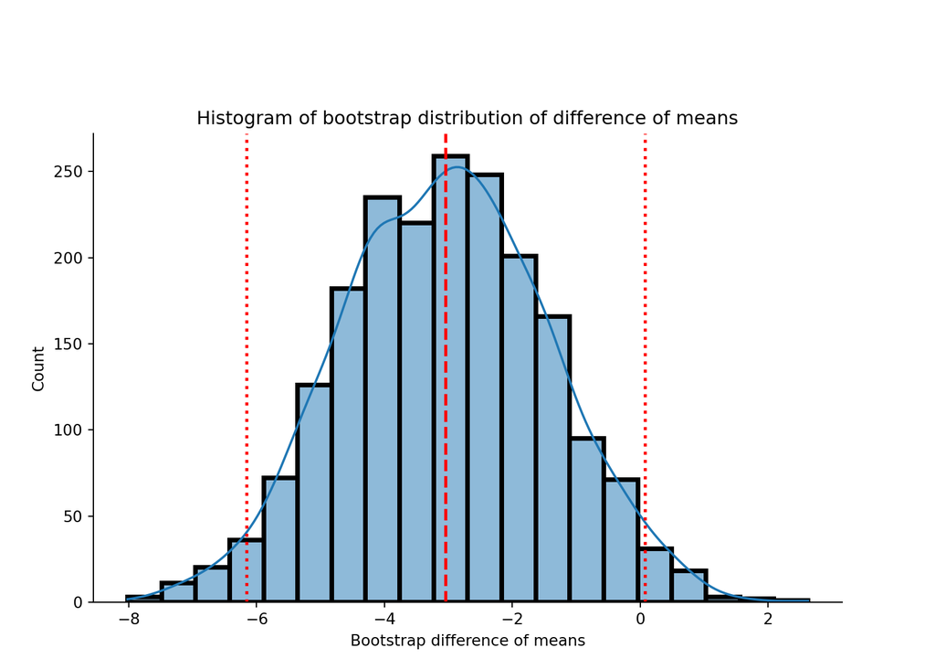

# Summary

Bootstrap estimation is widely useful and requires minimal assumption

- Bootstrap distribution is comprised of values of the statistic computed from bootstrap resamples of the original observations (data sample)
- Computing bootstrap distribution requires **no assumptions about population distribution!**
  - Bootstrap resampling substitutes computer power for paper and pencil statistician power
- Bootstrap resampling estimates the **bootstrap distribution** of a statistic
  - Compute mostly likely point estimate of the statistic, or bootstrap estimate
  - The bootstrap confidence interval is computed from the bootstrap distribution

# Summary

There are several variations of the basi nonparametric bootstrap algorithm

- One sample bootstrap
  - Inference on single populations
- Two sample bootstrap
  - Inference on different populations
- Special cases
  - Correlation coefficients - part of your assignment

# Summary

Re-sampling methods are general and powerful but, there is no magic involved! There are pitfalls!

- If a sample is biased, the re-sampled statistic estimate based on that sample will be biased
  - Results can be no better than the sample you start with
  - Example; the bootstrap estimate of mean is the unbiased sample estimate, $\bar{x}$, not the population parameter, $\mu$
- The sample variance and Cis can be no better than the sample distribution allows
  - Be suspicious of overly optimistic confidence intervals
  - CIs can be optimistically biased
- Are computationally intensive, but often highly parallelizable